# Workshop 4 Fiancial Econometrics

Juan David Torres

Mar 3 2021

# 2. Simple Regression Model

# Data download

Downloading data from ALFAA.MX and the ^MXX

```r
library(quantmod)
getSymbols(c("ALFAA.MX", "^MXX"), from="2015-01-01", to= "2019-12-31", periodicity="monthly", src="yahoo")
```

[output not shown]

```
## [1] "ALFAA.MX" "^MXX"
```

Calculation of CC Returns omitting the na values

```r
r_ALFAA <- na.omit(diff(log(ALFAA.MX$ALFAA.MX.Adjusted)))

r_MXX <- na.omit(diff(log(MXX$MXX.Adjusted)))
```

Merge of both variables in a single variable and renaming of the columns

```r
all_rets <- merge(r_ALFAA, r_MXX)
colnames(all_rets) <- c("ALFAA", "MXX")
```

# Visualize the relationship

Plotting the returns of both values

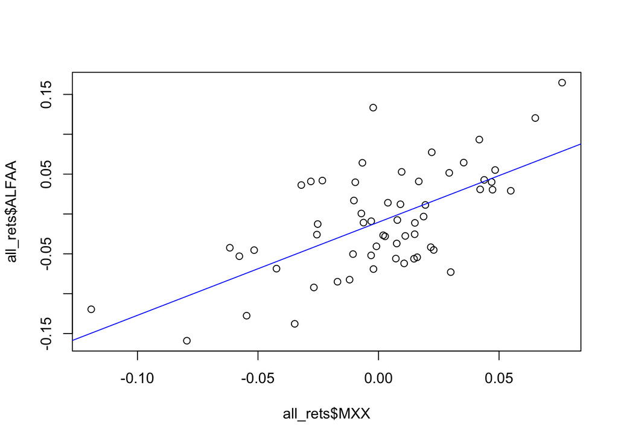

```r
plot.default(x=all_rets$MXX,y=all_rets$ALFAA)
abline(lm(all_rets$ALFAA ~ all_rets$MXX),col='blue')
```

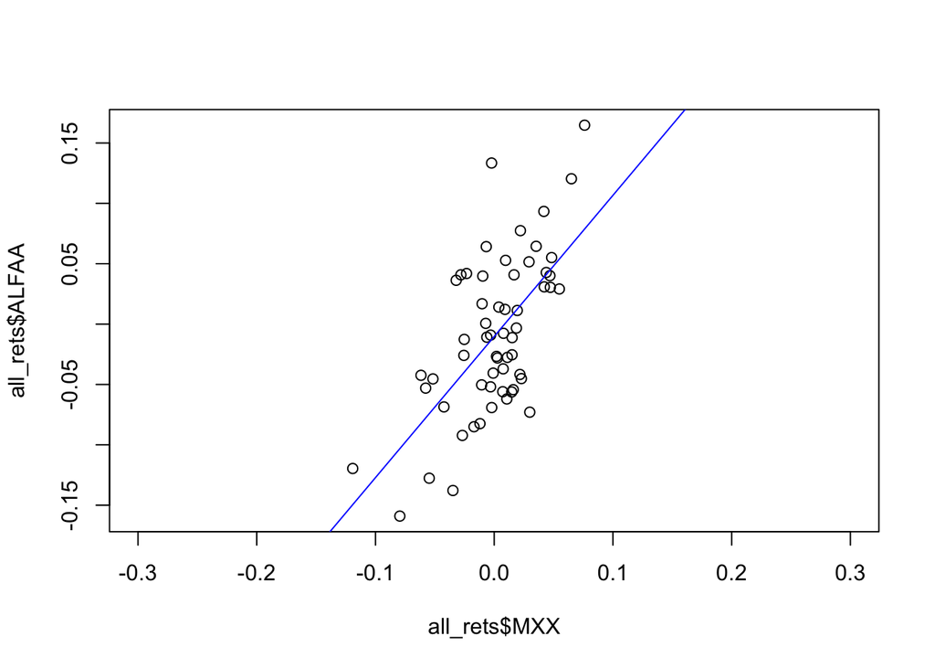

```r
plot.default(x=all_rets$MXX,y=all_rets$ALFAA, xlim=c(-0.30,0.30) )
abline(lm(all_rets$ALFAA ~ all_rets$MXX),col='blue')
```

Q: WHAT DOES THE PLOT TELL YOU? A: IT SHOWS THAT THE ALFA AND THE MXX HAVE A LINEAR BEHAVIOUR WITH A POTIVE RELATIONSHIP WHICH MEANS THAT WHEN ONE OF THE VARIABLES GO UP THE OTHER ONE WILL GO UP AS WELL.

# Running the market regression model

Calculate The Market Regression Model with the dependent variable being the ALFAA and the explanatory variable in this case MXX.

Run the regression model

```r
reg <- lm(r_ALFAA ~ r_MXX)
```

Get the summary of the regression output into a variable

```r
sumreg<- summary(reg)
sumreg
```

```
##
## Call:
## lm(formula = r_ALFAA ~ r_MXX)
##
## Residuals:
##       Min        1Q    Median        3Q       Max
## -0.097701 -0.036862 -0.004467  0.030768  0.146265
##
## Coefficients:
##              Estimate Std. Error t value Pr(>|t|)
## (Intercept) -0.010262   0.006643  -1.545    0.128
## r_MXX        1.168891   0.187738   6.226 6.11e-08 ***
## ---
## Signif. codes:  0 '***' 0.001 '**' 0.01 '*' 0.05 '.' 0.1 ' ' 1
##
## Residual standard error: 0.051 on 57 degrees of freedom
## Multiple R-squared:  0.4048, Adjusted R-squared:  0.3944
## F-statistic: 38.77 on 1 and 57 DF,  p-value: 6.113e-08
```

Calculation of main sums of squares

Calculate the mean of the dependent variable Y

```r
meanY = mean(r_ALFAA)
```

Calculate squared deviations of each value of Y from its mean and get the sums of the vvalues

```r
squared_deviations_1 <- (r_ALFAA - meanY)^2

SST = sum(squared_deviations_1)
SST
```

```
## [1] 0.2491151
```

Check if sum of squares calculation is correct

```r
anova(reg)
```

|  | Df | Sum Sq | Mean Sq | F value | Pr(>F) |
| --- | --- | --- | --- | --- | --- |
| r_MXX | 1 | 0.1008404 | 0.100840351 | 38.76519 | 6.113028e-08 |
| Residuals | 57 | 0.1482748 | 0.002601312 | NA | NA |

RESPOND TO THE FOLLOWING QUESTIONS

1. What are the standard errors of the beta coefficients? (b0 and b1) What are they for? b0: 0.006643 b1: 0.187738

IS THE STANDARD DEVIATION OF THE VARIABLES WE CAN USE THE STD ERROR TO ESTIMATE HOW MUCH THE BETA WILL FLUCTUATE IN AVERAGE IN THE FUTURE, YOU CAN ALSO USE IT TO CALUCLATE THE CONFIDENCE INTERVALS.

2. What is the total sum of squares (SST) ? (provide the result, and explain the formula)

```r
SST
```

```
## [1] 0.2491151
```

The formula is the sum of the squared difference between y and the mean of y. The deviations shows how each observation of the dependent variable Y is deviated from the mean.

3. What is the sum of squared errors (SSE) ? (provide the result, and explain the formula)

```r
# ∑( Yi - h(Yi))^2
hypY = 1.168891*r_MXX  - 0.010262
SSE = sum((r_ALFAA-hypY)^2)
SSE
```

```
## [1] 0.1482748
```

The formula is the sum of the squared difference between the real value of Y and the estimated value of Y using the coefficients b0 and b1 and the linear regression formula y= b1*x + b0. These represents how much of the total deviations of Y are not explained by the regression model.

4. What is the sum of squared regression differences (SSR) ? (provide the result and explain the formula)

```r
# ∑( h(Yi) - meanY)^2
SSRM = sum((hypY-meanY)^2)
SSRM
```

```
## [1] 0.1008404
```

The SSRM is the sum of the squared difference between the predicted Y and the mean of Y. These represents the squared deviations from the linear regression model.

5. What is the coefficient of determination of the regression (the R-squared)? (provide the result and explain the formula)

```r
#R^2 = SSRM/SST
#R^2 = 1 - (SSE/SST)
#Used both formulas and they gave mostly the same values
R2 = SSRM/SST
R2
```

```
## [1] 0.4047943
```

```r
R2 = 1 - (SSE/SST)
R2
```

```
## [1] 0.4047941
```

6. Interpret the results of the beta coefficients (b0 and b1) and their corresponding t-values and p-values with your own words.

TValue = Estimate-h0/stderror

Beta 0 Coefficient

b0 = -0.010262 t-value = -1.545 p-value = 0.128

Beta 1 Coefficient

b1 = 1.168891 t-value = 6.226 p-value = 6.11e-08

7. Estimate an approximate 95% confidence interval for b0 and b1 and interpret them

b0 = -0.010262 0.006643

```r
ci_left_b0 = -0.010262 - 1.96*0.006643
ci_right_b0 = -0.010262 + 1.96*0.006643

ci_left_b0
```

```
## [1] -0.02328228
```

```r
ci_right_b0
```

```
## [1] 0.00275828
```

This means that there is a probability of 95% that the value of b0 is between -0.02328228 and 0.00275828.

b1 = 1.168891 0.187738

```r
ci_left_b1 = 1.168891 - 1.96*0.187738
ci_right_b1 = 1.168891 + 1.96*0.187738

ci_left_b1
```

```
## [1] 0.8009245
```

```r
ci_right_b1
```

```
## [1] 1.536857
```

This means that there is a probability of 95% that the value of b1 is between 0.8009245 and 1.536857

# 3. Estimating the CAPM model for a stock

# 4 The CAPM model

# 5 Data colection

Load the library and get the environment ready

```r
rm(list=ls())

options(scipen=999)

library(quantmod)
```

# 5.1 Download stock data

Download the values of Apple, Tesla and the S&P500

```r
getSymbols(c("AAPL", "^GSPC", "TSLA"), from="2014-01-01", to="2020-12-01", periodicity="monthly", src="yahoo")
```

```
## [1] "AAPL"  "^GSPC" "TSLA"
```

Merge all the variables and calculate the CC Returns

```r
prices <- merge(AAPL$AAPL.Adjusted,GSPC$GSPC.Adjusted, TSLA$TSLA.Adjusted)

prices <- merge(Ad(AAPL), Ad(GSPC), Ad(TSLA))


APPL_r <- na.omit(diff(log(prices$AAPL.Adjusted)))
GSPC_r <- na.omit(diff(log(prices$GSPC.Adjusted)))
TSLA_r <- na.omit(diff(log(prices$TSLA.Adjusted)))
```

# 5.2 Download the risk free data from the FED

```r
getSymbols("TB3MS", src = "FRED")
```

```
## [1] "TB3MS"
```

Get the annual rate to monthly simple returns

```r
rfrate<-TB3MS/100/12
```

Use the formula to get cc returns

```r
rfrate <- log(1+rfrate)
```

# 5.3 Sub-setting the risk free dataset

```r
rfrate <- rfrate["2014-02-01/2020-12-01"]
```

# 5.4 Estimating premium returns

```r
TSLA_Premr <- TSLA_r - rfrate
APPL_Premr <- APPL_r - rfrate
GSPC_Premr <- GSPC_r - rfrate
```

# 6. Visualize the relationship

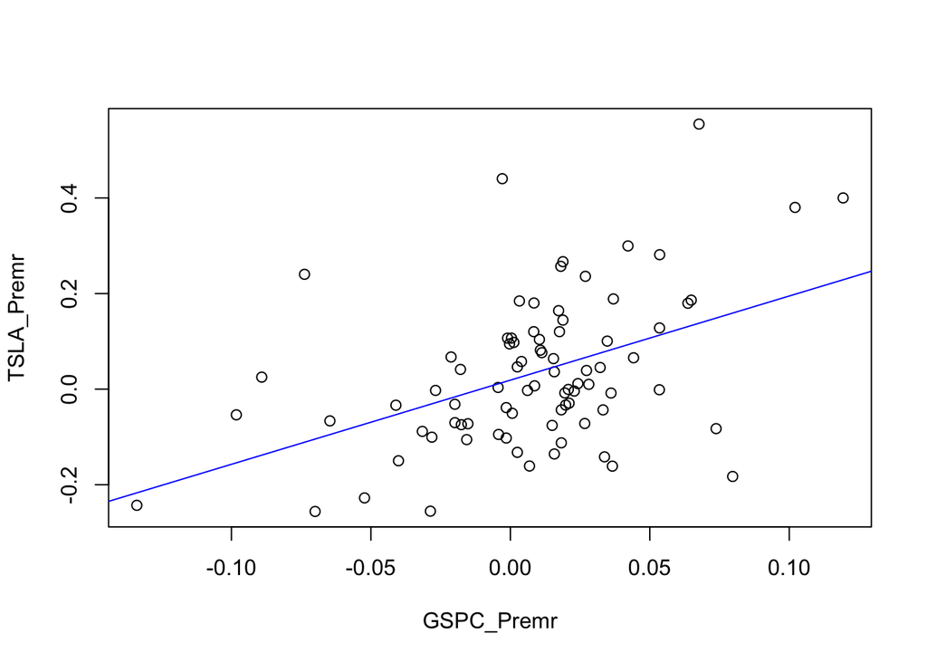

```r
plot.default(x=GSPC_Premr, y=TSLA_Premr)
abline(lm(TSLA_Premr ~ GSPC_Premr),col='blue')
```

Change the range

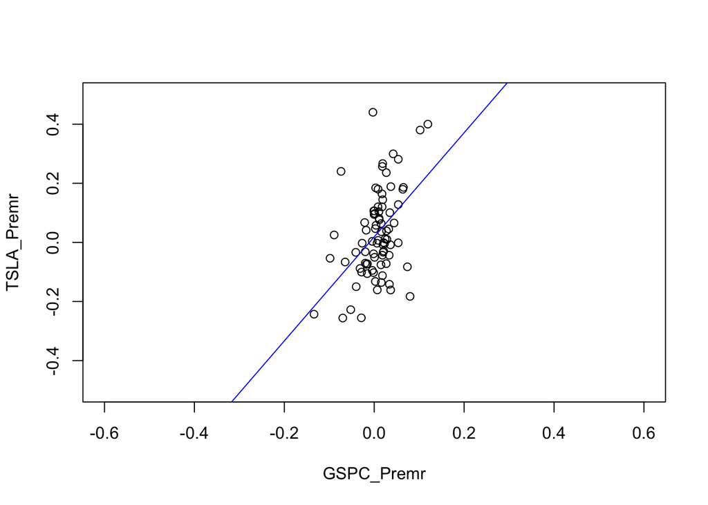

```r
plot.default(x=GSPC_Premr, y=TSLA_Premr, ylim=c(-0.5,0.5),xlim=c(-0.6,0.6))
abline(lm(TSLA_Premr ~ GSPC_Premr),col='blue')
```

Q: WHAT DOES THE PLOT TELL YOU? BRIEFLY EXPLAIN A: THE PLOT SHOW THAT THERE IS A POSITIVE LINEAR RELATION BETWEEN THE S&P500 PREMIUM RETURNS AND THE TESLA STOCK PREMIUM RETURNS. THIS MEANS THAT WHEN THE MARKET INCREASES ITS PRM RETURNS THE TESLA STOCK ALSO INCREASES ITS PRM RETURNS THE LINE LOOKS VERY STEEP WHICH MEANS THAT THE SLOPE IS VERY HIGH, THAT WHEN THE MARKET INCREASES THE RETURNS THE TESLA STOCK RETURNS INCREASE EVEN MORE.

# 7. Estimating the CAPM model for a stock

Use the premium returns to run the CAPM regression model for every stock.

# Calculate CAPM model of Tesla

```r
Tesla_CAPM <-lm(TSLA_Premr ~ GSPC_Premr, na.action=na.omit)

Tesla_s <-summary(Tesla_CAPM)

Tesla_s
```

```
##
## Call:
## lm(formula = TSLA_Premr ~ GSPC_Premr, na.action = na.omit)
##
## Residuals:
##      Min       1Q   Median       3Q      Max
## -0.34187 -0.08967 -0.02076  0.08358  0.42657
##
## Coefficients:
##             Estimate Std. Error t value  Pr(>|t|)
## (Intercept)  0.01884    0.01589   1.186     0.239
## GSPC_Premr   1.76090    0.38245   4.604 0.0000154 ***
## ---
## Signif. codes:  0 '***' 0.001 '**' 0.01 '*' 0.05 '.' 0.1 ' ' 1
##
## Residual standard error: 0.1413 on 80 degrees of freedom
## Multiple R-squared:  0.2095, Adjusted R-squared:  0.1996
## F-statistic:  21.2 on 1 and 80 DF,  p-value: 0.00001538
```

Estimation of 95% confidence intervals for B0 Tesla

```r
minB0 <- Tesla_s$coefficients[1,1]  - (2* Tesla_s$coefficients[1,2] )
maxBO <-  Tesla_s$coefficients[1,1]  + (2* Tesla_s$coefficients[1,2] )

cat("The approx. B0 confidence interval goes from", minB0, "to", maxBO)
```

```
## The approx. B0 confidence interval goes from -0.01294225 to 0.05062803
```

Estimation of 95% confidence intervals for B1 Tesla

```r
minB1 <- Tesla_s$coefficients[2,1]  - (2* Tesla_s$coefficients[2,2] )
maxB1 <-  Tesla_s$coefficients[2,1]  + (2* Tesla_s$coefficients[2,2] )

cat("The approx. B1 confidence interval goes from", minB1, "to", maxB1)
```

```
## The approx. B1 confidence interval goes from 0.9959955 to 2.525798
```

# Calculate CAPM model of Apple

```r
Apple_CAPM <-lm(APPL_Premr ~ GSPC_Premr, na.action=na.omit)

Apple_s <-summary(Apple_CAPM)

Apple_s
```

```
##
## Call:
## lm(formula = APPL_Premr ~ GSPC_Premr, na.action = na.omit)
##
## Residuals:
##       Min        1Q    Median        3Q       Max
## -0.238842 -0.029580 -0.001329  0.039277  0.128609
##
## Coefficients:
##             Estimate Std. Error t value       Pr(>|t|)
## (Intercept) 0.013915   0.006834   2.036          0.045 *
## GSPC_Premr  1.242986   0.164456   7.558 0.000000000059 ***
## ---
## Signif. codes:  0 '***' 0.001 '**' 0.01 '*' 0.05 '.' 0.1 ' ' 1
##
## Residual standard error: 0.06074 on 80 degrees of freedom
## Multiple R-squared:  0.4166, Adjusted R-squared:  0.4093
## F-statistic: 57.13 on 1 and 80 DF,  p-value: 0.00000000005901
```

Estimation of 95% confidence intervals for B0 Apple

```r
minB0 <- Apple_s$coefficients[1,1]  - (2* Apple_s$coefficients[1,2] )
maxBO <-  Apple_s$coefficients[1,1]  + (2* Apple_s$coefficients[1,2] )

cat("The approx. B0 confidence interval goes from", minB0, "to", maxBO)
```

```
## The approx. B0 confidence interval goes from 0.0002470664 to 0.02758273
```

Estimation of 95% confidence intervals for B1 Apple

```r
minB1 <- Apple_s$coefficients[2,1]  - (2* Apple_s$coefficients[2,2] )
maxB1 <-  Apple_s$coefficients[2,1]  + (2* Apple_s$coefficients[2,2] )

cat("The approx. B1 confidence interval goes from", minB1, "to", maxB1)
```

```
## The approx. B1 confidence interval goes from 0.9140729 to 1.571899
```

1. INTERPRET THE RESULTS OF THE COEFFICIENTS (b0 and b1), THEIR STANDARD ERRORS, P-VALUES AND 95% CONFIDENCE INTERVALS.

# TESLA CAPM

B0

B0 IS THE EXPECTED EXCESS RETURN IN A MONTHLY FREQUENCY. IN THIS CASE FOR TESLA 0.01884 IS THE ESTIMATING ASSET EXPECTED EXCESS RETURN IN OTHER WORDS WHEN THE MARKET PREMIUM RETURNS ARE 0 THE TESLA PREMIUM RETURNS ARE GOING TO BE EQUAL TO THE B0.

THE STANDARD ERROR OF B0 IS 0.01589 WHICH MEANS THAT THE B0 CAN FLUCTUATE IN A MAGNITUDE OF 0.01589 THE T-VALUE IS 1.186 AND BECAUSE IT IS LOWER THAN 2 THE NULL HYPOTHESIS THAT IS THAT B0=0 ISN’T REJECTED WHICH MEANS THAT THERE IS NO 95% PROBABILITY THAT THE VALUE IS DIFFERENT THAN 0. THIS ALSO MEANS THAT THERE COULD BE NO EXCESS OF RETURNS

B1

B1 IS THE A WAY TO ESTIMATE THE MARKET SYSTEMATIC RISK BETWEEN THE ASSET AND THE MARKET RISK PREMIUMS. THIS MEANS THAT THE TESLA PREMIUMS CAN INCREASE IN 1.76090 TIMES WHEN THE MARKET PREMIUMS CHANGE IN 1 UNIT.

THE STANDARD ERROR IS 0.38245 WHICH MEANS THAT THE B1 CAN FLUCTUATE IN THAT AMOUNT AND THAT IS THE RISK OF THE TESLA STOCK PREMIUMS. THE T-VALUE IS 4.604 THIS MEANS THAT BECAUSE IT IS HIGHER THAN 2 THAT THE NULL HYPOTHESIS CAN BE REJECTED. IN OTHER WORDS THERE IS RELATION BETWEEN THE TESLA PREMIUMS AND THE MARKET PREMIUMS.

THE P-VALUE IS 0.0000154 AND BECAUSE IT IS SMALLER THAN 0.05 SO THE NULL HYPOTHESIS IS REJECTED AND THE B1 IS NOT GOING TO BE 0.

THE APPROX. B1 CONFIDENCE INTERVAL GOES FROM 0.9959955 TO 2.525798 WHICH MEANS THAT WITH 95% CONFIDENCE THE VALUES OF B1 FLUCTUATES BETWEEN THOSE VALUES

# APPLE CAPM

B0

B0 IS THE EXPECTED EXCESS RETURN IN A MONTHLY FREQUENCY. IN THIS CASE FOR APPLE 0.013915 IS THE ESTIMATING ASSET EXPECTED EXCESS RETURN IN OTHER WORDS WHEN THE MARKET PREMIUM RETURNS ARE 0 THE APPLE PREMIUM RETURNS ARE GOING TO BE EQUAL TO THE B0.

THE STANDARD ERROR OF B0 IS 0.006834 WHICH MEANS THAT THE B0 CAN FLUCTUATE IN A MAGNITUDE OF 0.006834.

THE T-VALUE IS 2.036 AND BECAUSE IT IS HIGHER THAN 2 THE NULL HYPOTHESIS THAT IS THAT B0=0 CAN BE REJECTED WHICH MEANS THAT THERE IS A 95% PROBABILITY THAT THE VALUE IS DIFFERENT THAN 0. THIS ALSO MEANS THAT THERE WILL BE AN EXCESS OF RETURNS.

THE P-VALUE IS 0.045 WHICH MEANS ONCE AGAIN THAT BECAUSE IS SMALLER THAN 0.05 THE NULL HYPOTHESIS CAN BE REJECTED AND THAT THE EXCESS OF RETURNS COULD NOT BE 0 WITH A 95% CONFIDENCE.

THE APPROX. B0 CONFIDENCE INTERVAL GOES FROM 0.0002470664 TO 0.02758273 THIS MEANS THAT WITH A 95% CONFIDENCE THE VALUES OF B0 CAN FLUCTUATE BETWEEN 0.0002470664 TO 0.02758273 AND WILL NOT BE 0.

B1

B1 IS THE A WAY TO ESTIMATE THE MARKET SYSTEMATIC RISK BETWEEN THE ASSET AND THE MARKET RISK PREMIUMS. THIS MEANS THAT THE APPLE PREMIUMS CAN INCREASE IN 1.242986 TIMES WHEN THE MARKET PREMIUMS CHANGE IN 1 UNIT.

THE STANDARD ERROR IS 0.164456 WHICH MEANS THAT THE B1 CAN FLUCTUATE IN THAT AMOUNT AND THAT IS THE RISK OF THE APPLE STOCK PREMIUMS. THE T-VALUE IS 7.558 THIS MEANS THAT BECAUSE IT IS HIGHER THAN 2 THAT THE NULL HYPOTHESIS CAN BE REJECTED. IN OTHER WORDS THERE IS RELATION BETWEEN THE APPLE PREMIUMS AND THE MARKET PREMIUMS.

THE P-VALUE IS 0.000000000059 AND BECAUSE IT IS SMALLER THAN 0.05 SO THE NULL HYPOTHESIS IS REJECTED AND THE B1 IS NOT GOING TO BE 0.

THE APPROX. B1 CONFIDENCE INTERVAL GOES FROM 0.9140729 TO 1.571899 B1 FURTHERMORE FLUCTUATES BETWEEN THOSE TWO VALUES

2. DO A QUICK RESEARCH ABOUT THE EFFICIENT MARKET HYPOTHESIS. BRIEFLY DESCRIBE WHAT THIS HYPOTHESIS SAYS.

THE EFFICIENT MARKET HYPOTHESIS STATES THAT SHARE PRICES REFLECT ALL THE INFORMATION SO IT IS IMPOSSIBLE TO BEAT THE MARKET WHICH MEANS THAT THERE IS NO WAY TO MAKE A PROFIT WITH A TRADING STRATEGY. THE ONLY WAY TO GET HIGHER RETURNS THAN THE ONES FROM AN INDEX IS PURSHASING HIGHER RISK INVESTMENTS.

THIS MEANS THAT IT IS IMPOSSIBLE FOR INVESTORS TO PURSHASE UNDERVALUED STOCKS OR SELL STICKS FOR INFLATED PRICES. THIS MEANS THAT IS IMPOSSIBLE TO OUTPERFORM THE MARKET THROGUH TRADING STRATEGIES.

3. ACCORDING TO THE EFFICIENT MARKET HYPOTHESIS, WHAT IS THE EXPECTED VALUE OF b0 in the CAPM REGRESSION MODEL?

IN THIS CASE THE B0 BECAUSE IT IS THE EXCESS OF RETURNS AND DUE TO THE FACT THAT THE EMH STATES THAT THE PRICES ARE ALREADY IN A FAIR VALUE THE B0 WILL BE 0 BECAUSE THERE WILL BE NO EXCESS.

4. ACCORDING TO YOUR RESULTS, IS TESLA SIGNIFICANTLY RISKIER THAN THE MARKET ? WHAT IS THE t-test YOU NEED TO DO TO RESPOND THIS QUESTION? Do the test and provide your interpretation. (Hint: Here you have to change the null hypothesis for b1: H0: b1=1; Ha=b1<>1)

```r
# Null hypothesis and alternative hypothesis
# H0: b1 = 1
# Ha: b1 <>1

# Calculation of the standard error
se_TSLA <- Tesla_s$coefficients[2,2]

# Calculation of the t-value. The 0 below is the H0
t_val_TSLA <- (Tesla_s$coefficients[2,1] - 1) / se_TSLA
cat("t-value H0: b1 = 1 AAPL = ", t_val_TSLA)
```

```
## t-value H0: b1 = 1 AAPL =  1.989529
```

THE T VALUE GIVEN THE NEW NULL HYPOTHESIS IS 1.989529 WHICH IS SMALLER THAN 2 AND THIS MEANS THAT THE NULL HYPOTHESIS CAN’T BE REJECTED MEANING THAT IS NOT SIGNIFICANTLY RISKIER BECAUSE IT CANNOT BE PROVED THAT B1 IS DIFFERENT THAN 1. THERE IS NO STATISTICAL EVEDIENCE TO SAY WITH 95% OF CONFIDENCE THAT B1 IS GREATER THAN 1 WHICH CONCLUDES THAT THE MARKET PREMIUM RETURNS ARE ALMOST THE SAME AS THE MARKET RETURNS.

ALTHOUGH THE VALUE IS VERY CLOSE TO 2 THERE CAN BE NO CERTAINITY TO SAY THAT THE B1 IS DIFFERENT THAN 1.